[figure not shown]

##### **Author:** *Giovanni Giunta*

##### **Matricola:** *1177327*

##### **Subject:** *Statistical Methods for Data Science - II*

##### **Course:** *Data Science*

##### **University:** *La Sapienza University of Rome*

## **First Exercise**

### 1a) Illustrate the characteristics of the statistical model for dealing with the Dugong’s data

In the R script titled “2022-W-13-R2jags-code.R” we have been provided with the age and length of 27 Dugongs. First we store all the information we have into a list, then we plot the age and length of our Dugongs and we immediately notice, as shown below, that there is a clear non linear relationship between these two variables.

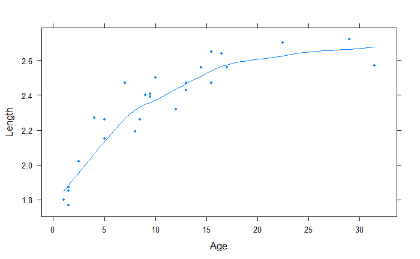

```r
library(lattice)

mydata <- list(
  X = c( 1.0,  1.5,  1.5,  1.5, 2.5,   4.0,  5.0,  5.0,  7.0, 8.0,  8.5,  9.0,  9.5, 9.5,  10.0, 12.0, 12.0, 13.0, 13.0, 14.5, 15.5, 15.5, 16.5, 17.0, 22.5, 29.0, 31.5),

  Y = c(1.80, 1.85, 1.87, 1.77, 2.02, 2.27, 2.15, 2.26, 2.47, 2.19, 2.26, 2.40, 2.39, 2.41, 2.50, 2.32, 2.32, 2.43, 2.47, 2.56, 2.65, 2.47, 2.64, 2.56, 2.70, 2.72, 2.57),
  N = 27
)

xyplot(mydata$Y ~ mydata$X, type=c("smooth", "p"), xlab="Age", ylab="Length", pch=20 )
```

```r
NA
NA
```

In fact, a non-linear regression model would explain perfectly the given data. As indicated in the assignment specifications, we can consider the following non-linear regression model:

$$\begin{equation}
Y_i \sim N( \mu_i, \tau^2 ) \\
\mu_i = f(x_i) = \alpha - \beta \gamma^{x_i}
\end{equation}$$

### 1b) Derive the corresponding likelihood function

If we assume that every $Y_{i}$ is independent and identically distributed with each other, then we can define our likelihood function as:

$$\begin{equation}
L_{Y_{obs}}(Y_{1},...,Y_{n} | \alpha, \beta, \gamma, x_{i}, \tau^{2})
\quad = \quad \prod_{i=1}^{n} f(Y_i|\alpha, \beta, \gamma, x_{i},
\tau^{2}) \quad
\end{equation}$$

We also know that $Y_{i} \sim N(\mu_{i}, \tau^{2})$, so we can go on and write:

$$\begin{equation}
\quad \prod_{i=1}^{n} f(Y_i|\alpha, \beta, \gamma, x_{i}, \tau^{2})
\quad = \quad \prod_{i=1}^{n} \frac{1}{\sqrt{2\pi\tau^{2}}}
exp\Big\{-\frac{1}{2\tau^{2}} ( Y_{i} - \mu_{i})^{2} \Big\} \\
= \quad \prod_{i=1}^{n}{(2\pi \tau^2)^{-n/2} exp\Big\{-\frac{1}{2\tau^2}
{(Y_i-\left(\alpha - \beta \gamma^{x_i}\right))^2}} \Big\}
\quad = \quad (2\pi\tau^{2})^{-\frac{n}{2}} exp\Big\{
-\frac{1}{2\tau^{2}} \sum_{i=1}^{n}\Big[ Y_{i} - (\alpha -
\beta\gamma^{x_{i}})\Big]^{2} \Big\}
\end{equation}$$

### 1c) Write down the expression of the joint prior distribution of the parameters at stake and illustrate your suitable choice for the hyperparameters

By assuming that the prior distributions of the model parameters are independent from each other, then their joint distribution is:

$$\begin{equation}
\pi(\alpha, \beta, \gamma, \tau^2) \quad = \quad \pi(\alpha) \pi(\beta)
\pi(\gamma) \pi(\tau^2) \\
= \quad (2\pi \sigma^2_\alpha)^{-1/2}
exp\Big\{-\frac{(\alpha-0)^2}{2\sigma^2_\alpha} \Big\} \cdot
(2\pi \sigma^2_\beta)^{-1/2}
exp\Big\{-\frac{(\beta-0)^2}{2\sigma^2_\beta} \Big\} \cdot
\frac{b^a}{\Gamma(a)} (\tau^2)^{-a-1} exp\Big\{-\frac{b}{\tau^2}\Big\}
\\
= \quad \frac{b^a}{2\pi \Gamma(a)} (\tau^2)^{-a-1} ( \sigma^2_\alpha
\sigma^2_\beta )^{-1/2} exp\Big\{-\frac{(\alpha)^2}{2\sigma^2_\alpha}
-\frac{(\beta)^2}{2\sigma^2_\beta} -\frac{b}{\tau^2}\Big\}
\end{equation}$$

Now, we are asked to come up with some suitable choices for the hyperparameters. We start with $\tau^{2}$, that is the variance of our observations $Y_{i}$. Since we know that $\tau^2 \sim IG(a, b)(Inverse Gamma)$, we need to choose appropriate values for $a, b$.

First, we note that the variance for the observed length of our Dugongs is:

```r
var(mydata$Y)
```

```
[1] 0.07543276
```

Hence, it seems appropriate to choose values for $a, b$ that make sure that the prior distribution is concentrated around our sample variance. Let’s investigate how the Inverse Gamma distribution looks like with some different values for $a, b$:

```r
library("invgamma")

a_vec <- c(1,10,20,30)
b_vec <- c(0,1.5,3,4.5)

sample_var <- var(mydata$Y)

curve(
  dinvgamma(x, shape=a_vec[1], rate=b_vec[1]),
  col=1,
  lwd=3,
  xlab=expression(paste(tau^2)),
  ylab=expression(paste(pi(tau^2))),
  ylim=c(0,25),
  xlim=c(0,0.4)
)

for (i in 2:length(a_vec)){
  for (j in 2:length(b_vec)){
    curve(
      dinvgamma(x,shape=a_vec[i], rate=b_vec[j]),
      add=T,
      lwd=3,
      col=i+j,
      ylim=c(0,25),
      xlim=c(0,0.4)
    )
  }
}
```

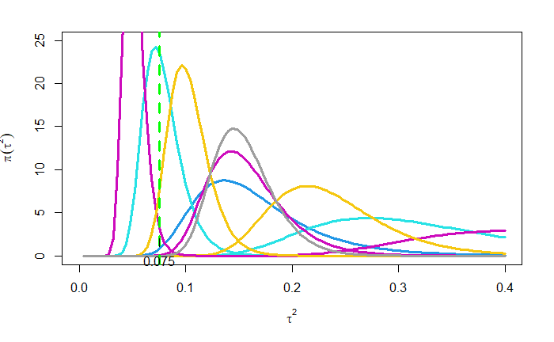

```r
abline(v = sample_var, col="green", lwd=3, lty=2)

axis(1, at = sample_var, labels = round(sample_var, 3), pos = 2)
```

As we can see, the turquoise one is the most concentrated around the sample variance. Then, $a = 20, b = 1.5$ are going to be our choice.

We can take a better look at it in the plot below:

```r
curve(
  dinvgamma(x, shape=20, rate=1.5),
  col="turquoise",
  lwd=3,
  xlab=expression(paste(tau^2)),
  ylab=expression(paste(pi(tau^2))),
  ylim=c(0,25),
  xlim=c(0,0.3)
)

abline(v = sample_var, col="green", lwd=3, lty=2)
```

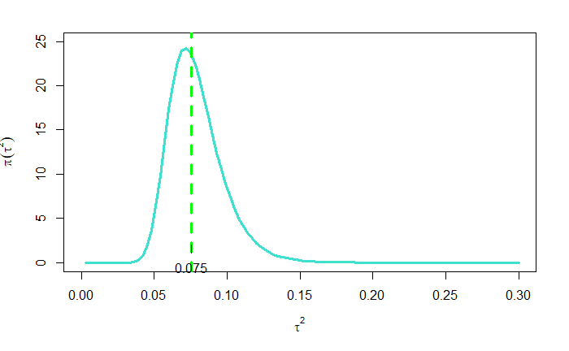

```r
axis(1, at = sample_var, labels = round(sample_var, 3), pos = 2)
```

```r
regression <- lm(mydata$Y ~ mydata$X, data = mydata)

intercept <- regression$coefficients[1]
slope <- regression$coefficients[2]

intercept
```

```
(Intercept)
   2.019769
```

Using the same logic as before, we run again some simulations to come up with the best possible choice for the unknown variance of $\alpha$, only this time by looking for the best possible candidate with respect to the value of the intercept:

```r
candidates <- c(1,5,10,15,30)

curve(
  dnorm(x, mean = 0,sd = sqrt(candidates[1])),
  col=1,
  lwd=3,
  xlab=expression(alpha),
  ylab=expression(paste(pi(alpha))),
  ylim=c(0,0.5),
  xlim=c(-6,6)
)

for (i in 2:length(candidates)){
  curve(
    dnorm(x,mean = 0,sd = sqrt(candidates[i])),
    add=T,
    lwd=3,
    col=i
  )
}
```

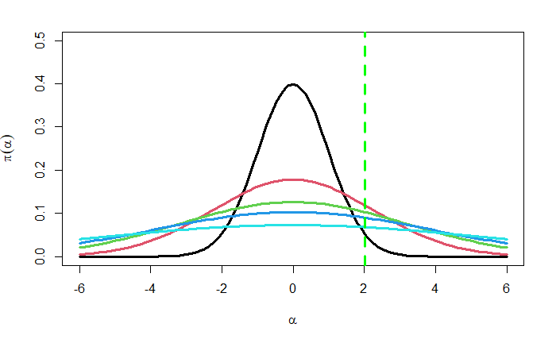

```r
abline(v = intercept, col="green", lwd=3, lty=2)
```

A good compromise in this case might be to choose a value for $\sigma^{2}_{\alpha} = 5$, so that we avoid having a prior that is too much non-informative, while still “containing” the estimated value of the intercept:

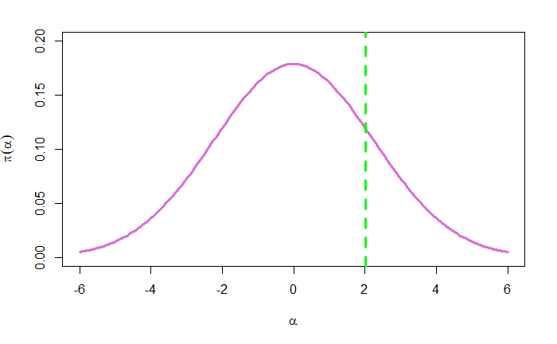

```r
curve(
  dnorm(x, mean = 0,sd = sqrt(5)),
  col="orchid",
  lwd=3,
  xlab=expression(alpha),
  ylab=expression(paste(pi(alpha))),
  ylim=c(0,0.2),
  xlim=c(-6,6)
)

abline(v = intercept, col="green", lwd=3, lty=2)
```

We can do the same thing with the variance for $\beta$, that is $\sigma^{2}_{\beta}$:

```r
candidates <- c(0.01,0.05,0.1,0.2,0.3)

curve(
  dnorm(x, mean = 0,sd = sqrt(candidates[1])),
  col=1,
  lwd=3,
  xlab=expression(beta),
  ylab=expression(paste(pi(beta))),
  ylim=c(0,5),
  xlim=c(-1,1)
)

for (i in 2:length(candidates)){
  curve(
    dnorm(x,mean = 0,sd = sqrt(candidates[i])),
    add=T,
    lwd=3,
    col=i
  )
}
```

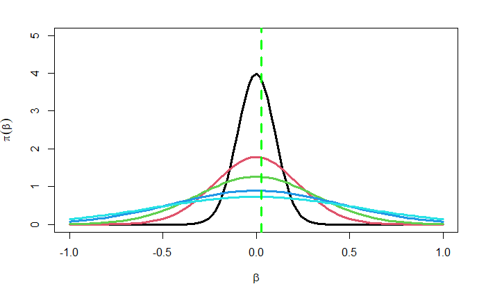

```r
abline(v = slope, col="green", lwd=3, lty=2)
```

In this case, we choose $\sigma^{2}_{\beta} = 0.05$.

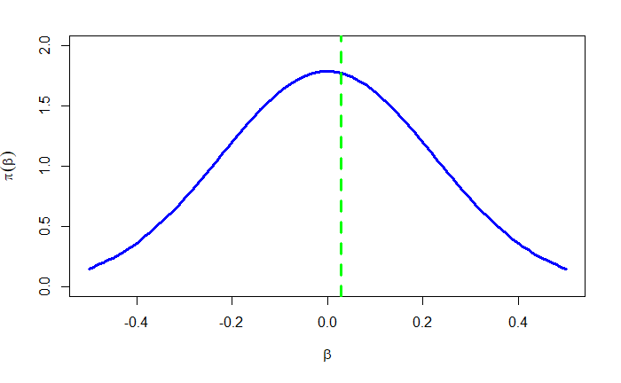

```r
curve(
  dnorm(x, mean = 0,sd = sqrt(0.05)),
  col="blue",
  lwd=3,
  xlab=expression(beta),
  ylab=expression(paste(pi(beta))),
  ylim=c(0,2),
  xlim=c(-0.5,0.5)
)

abline(v = slope, col="green", lwd=3, lty=2)
```

We don’t have to do basically anything about $\gamma$, as we already know its parameters, that are $0$ and $1$.

### 1d) Derive the functional form (up to proportionality constants) of all full-conditionals

In total we have to derive four full-conditionals, that are:

#### A) for $\tau^{2}$:

$$\begin{equation}
\pi(\tau^{2}|\alpha, \beta, \gamma, Y_{obs}) \propto \pi(Y_{obs}|\alpha,
\beta, \gamma, x_{i}, \tau^{2}) \pi(\tau^{2}) \propto \\
\propto \pi(Y_{obs}|\mu_{i}, \tau^{2}) \pi(\tau^{2}) \propto \\
\propto (2\pi\tau^{2})^{-\frac{n}{2}} \cdot exp\Big\{
-\frac{1}{2\tau^{2}} \sum_{i=1}^{n}\Big( Y_{i} - (\alpha -
\beta\gamma^{x_{i}})\Big)^{2} \Big\} \cdot (\tau^{2})^{-(a+1)} exp\Big\{
-\frac{b}{\tau^{2}} \Big\} \propto \\
\propto (\tau^{2})^{-\frac{n}{2}} \cdot exp\Big\{ -\frac{1}{2\tau^{2}}
\sum_{i=1}^{n}\Big( Y_{i} - (\alpha - \beta\gamma^{x_{i}})\Big)^{2}
-\frac{b}{\tau^{2}} \Big\} \cdot (\tau^{2})^{-(a+1)} \propto \\
\propto (\tau^{2})^{-(\frac{n}{2}+a+1)} \cdot exp\Big\{
-\frac{\sum_{i=1}^{n}( Y_{i} - (\alpha -
\beta\gamma^{x_{i}}))^{2}+b}{2\tau^{2}} \Big\}
\end{equation}$$

#### B) for $\alpha$:

$$\begin{equation}
\pi(\alpha|\tau^{2}, \beta, \gamma, Y_{obs}) \propto \pi(Y_{obs}|\alpha,
\beta, \gamma, x_{i}, \tau^{2}) \pi(\alpha) \propto \\
\propto \pi(Y_{obs}|\mu_{i}, \tau^{2}) \pi(\alpha) \propto \\
\propto (2\pi\tau^{2})^{-\frac{n}{2}} \cdot exp\Big\{
-\frac{1}{2\tau^{2}} \sum_{i=1}^{n}\Big( Y_{i} - (\alpha -
\beta\gamma^{x_{i}})\Big)^{2} \Big\} \cdot exp\Big\{
-\frac{(\alpha)^2}{2\sigma_{\alpha}^{2}} \Big\} \propto \\
\propto exp\Big\{ -\frac{1}{2\tau^{2}} \sum_{i=1}^{n}\Big( Y_{i} -
(\alpha - \beta\gamma^{x_{i}})\Big)^{2}
-\frac{(\alpha)^2}{2\sigma_{\alpha}^{2}} \Big\} \propto \\
\propto exp\Big\{ -\frac{1}{2\tau^{2}} \sum_{i=1}^{n} \Big( Y_{i}^{2} +
\alpha^{2} + \beta^{2}\gamma^{2x_{i}} - 2Y_{i}\alpha +
2Y_{i}\beta\gamma^{x_{i}} - 2\alpha\beta\gamma^{x_{i}} \Big)
-\frac{(\alpha)^2}{2\sigma_{\alpha}^{2}} \Big\} \propto \\
\propto exp\Big\{ -\frac{1}{2} \Big( \frac{n}{\tau^{2}} +
\frac{1}{\sigma_{\alpha}^{2}}\Big)\alpha^{2} + \Big(
\frac{\sum_{i=1}^{n} Y_{i} +
\beta\sum_{i=1}^{n}\gamma^{x_{i}}}{\tau^{2}} \Big)\alpha \Big\}
\end{equation}$$

#### C) for $\beta$:

$$\begin{equation}
\pi(\beta|\tau^{2}, \alpha, \gamma, Y_{obs}) \propto \pi(Y_{obs}|\alpha,
\beta, \gamma, x_{i}, \tau^{2}) \pi(\beta) \propto \\
\propto \pi(Y_{obs}|\mu_{i}, \tau^{2}) \pi(\beta) \propto \\
\propto (2\pi\tau^{2})^{-\frac{n}{2}} \cdot exp\Big\{
-\frac{1}{2\tau^{2}} \sum_{i=1}^{n}\Big( Y_{i} - (\alpha -
\beta\gamma^{x_{i}})\Big)^{2} \Big\} \cdot exp\Big\{
-\frac{(\beta)^2}{2\sigma_{\beta}^{2}} \Big\} \propto \\
\propto exp\Big\{ -\frac{1}{2\tau^{2}} \sum_{i=1}^{n}\Big( Y_{i} -
(\alpha - \beta\gamma^{x_{i}})\Big)^{2}
-\frac{(\beta)^2}{2\sigma_{\beta}^{2}} \Big\} \propto \\
\propto exp\Big\{ -\frac{1}{2\tau^{2}} \sum_{i=1}^{n} \Big( Y_{i}^{2} +
\alpha^{2} + \beta^{2}\gamma^{2x_{i}} - 2Y_{i}\alpha +
2Y_{i}\beta\gamma^{x_{i}} - 2\alpha\beta\gamma^{x_{i}} \Big)
-\frac{(\beta)^2}{2\sigma_{\beta}^{2}} \Big\} \propto \\
\propto exp\Big\{ -\frac{1}{2} \Big( \frac{\sum_{i=1}^{n}
\gamma^{2x_{i}}}{\tau^{2}} + \frac{1}{\sigma_{\beta}^{2}}\Big)\beta^{2}
+ \Big( \frac{ \alpha\sum_{i=1}^{n}\gamma^{x_{i}} -
\sum_{i=1}^{n}Y_{i}\gamma^{x_{i}} }{\tau^{2}} \Big)\beta \Big\}
\end{equation}$$

#### D) for $\gamma$:

$$\begin{equation}
\pi(\gamma|\tau^{2}, \alpha, \beta, Y_{obs}) \propto \pi(Y_{obs}|\alpha,
\beta, \gamma, x_{i}, \tau^{2}) \pi(\gamma) \propto \\
\propto \pi(Y_{obs}|\mu_{i}, \tau^{2}) \pi(\gamma) \propto \\
\propto (2\pi\tau^{2})^{-\frac{n}{2}} \cdot exp\Big\{
-\frac{1}{2\tau^{2}} \sum_{i=1}^{n}\Big( Y_{i} - (\alpha -
\beta\gamma^{x_{i}})\Big)^{2} \Big\} \cdot \frac{1}{1-0} \propto \\
\propto exp\Big\{ -\frac{1}{2\tau^{2}} \sum_{i=1}^{n}\Big( Y_{i} -
(\alpha - \beta\gamma^{x_{i}})\Big)^{2} \Big\}
\end{equation}$$

### 1e) Which distribution can you recognize within standard parametric families so that direct simulation from full conditional can be easily implemented ?

From the previously defined full-conditionals, we can recognize the following standard parametric families:

#### A) for $\tau^{2}$ we have:

$$\begin{equation}
\pi(\tau^2 | \alpha, \beta, \gamma, x, Y) \sim IG \Big(a + \frac{n}{2},
b + \frac{1}{2} \sum_{i=1}^n (Y_{i} - \alpha + \beta \gamma^{x_i})^2
\Big)
\end{equation}$$

#### B) for $\alpha$ we have:

$$\begin{equation}
\pi(\alpha|\beta, \gamma, \tau^2, x, Y) \sim N
\Big(\frac{\sigma_{\alpha}^2 \sum_{i=1}^n (Y_{i} + \beta
\gamma^{x_i})}{\tau^2 + n \sigma_{\alpha}^2}, \frac{\sigma_{\alpha}^2
\tau^2}{\tau^2 +n \sigma_{\alpha}^2} \Big)
\end{equation}$$

#### C) for $\beta$ we have:

$$\begin{equation}
\pi(\beta|\alpha, \gamma, \tau^2, x, Y) \sim N
\Big(\frac{\sigma_{\beta}^2 \sum_{i=1}^n \gamma^{x_i} (\alpha -
Y_{i})}{\tau^2 + \sigma_{\beta}^2 \sum_{i=1}^n \gamma^{2x_i}},
\frac{\sigma_{\beta}^2 \tau^2}{\tau^2 + \sigma_{\beta}^2 \sum_{i=1}^n
\gamma^{2x_i}}\Big)
\end{equation}$$

#### D) for $\gamma$ we have:

No standard parametric family was found…

### 1f) Using a suitable Metropolis-within-Gibbs algorithm simulate a Markov chain (T = 10000) to approximate the posterior distribution for the above model

We start by implementing the Metropolis-within-Gibbs algorithm for those full-conditionals that have been recognized as belonging to a known parametric family:

```r
fc_alpha <- function(sig_sq_alpha, beta, gamma, tau2, mydata){
  x <- mydata$X
  y <- mydata$Y
  n <- length(y)

  post_mu <- sig_sq_alpha / (n * sig_sq_alpha+tau2) * sum(y + beta * gamma^x)
  post_sig_sq <- sig_sq_alpha * tau2 / (n * sig_sq_alpha + tau2)

  result <- rnorm(n = 1, mean = post_mu, sd = sqrt(post_sig_sq))

  if(result < 1) {
    result <- 1
  }

  return(result)
}

fc_beta <- function(sig_sq_beta, alpha, gamma, tau2, mydata){
  x <- mydata$X
  y <- mydata$Y
  n <- length(y)

  post_mu <- sig_sq_beta / (sig_sq_beta * sum((gamma^(2*x))) + tau2) * sum((alpha - y)*gamma^x)
  post_sig_sq <- sig_sq_beta * tau2 / (sig_sq_beta * sum((gamma^x)^2 + tau2))


  result <- rnorm(n = 1, mean = post_mu, sd = sqrt(post_sig_sq))

  if(result < 1 ) {
    result <- 1
  }

  return(result)
}

fc_tau <- function(a, b, alpha, beta, gamma, mydata){
  x <- mydata$X
  y <- mydata$Y
  n <- length(y)

  post_a <- n/2 + a
  post_b <- 0

  for (i in 1:n){
    post_b <- post_b + (y[i]-(alpha-beta * gamma^x[i]))^2
  }

  post_b <- (post_b)/2 + b

  result <- rinvgamma(n = 1, shape = post_a, rate = post_b)

  return(result)
}
```

Given that no known parametric family has been identified for $\gamma$, we now make use of the Metropolis Hastings algorithm:

```r
fc_gamma <- function(alpha, beta, gamma, tau2, sig_sq_beta, mydata){
  x <- mydata$X
  y <- mydata$Y
  n <- length(y)

  post_gamma <- 0

  for (i in 1:n){
    post_gamma <- post_gamma + (y[i] - (alpha - beta * gamma^x[i]))^2
  }

  post_gamma <- (-1/(2*tau2))*post_gamma

  return(post_gamma)
}

mh_fc_gamma <- function(alpha, beta, first_gamma, tau2, mydata, mh_trials, seed){

  for(i in 1:mh_trials){
    set.seed(seed)      # at every n_iteration we change the seed, by incrementing its current value!

    gamma_ext <- runif(n = 1, min = 0, max = 1)

    num <- fc_gamma(
                alpha = alpha,
                beta = beta,
                gamma = gamma_ext,
                tau2 = tau2,
                sig_sq_beta = sig_sq_beta,
                mydata = mydata
            )

    den <- fc_gamma(
                alpha = alpha,
                beta = beta,
                gamma = first_gamma,
                tau2 = tau2,
                sig_sq_beta = sig_sq_beta,
                mydata = mydata
              )

    zz <- exp(num - den)

    zzmin <- min(zz,1)

    accept <- 0

    if (zzmin >= 1) {
      first_gamma <- gamma_ext
      accept <- 1
    }
    else
    {
      if (rbinom(1,1,zzmin)==1) {
        first_gamma <- gamma_ext
        accept <- 1
      }
    }

    seed <- seed + 100
  }

  return(c(new_beta=first_gamma, accept=accept)  )
}
```

Below we run the above implementation:

```r
a <- 20
b <- 1.5

sig_sq_alpha <- 5
sig_sq_beta <- 0.05

seed <- 123

n_n_iter <- 10000

out_matrix <- matrix(nrow = n_n_iter, ncol = 4)

out_matrix[1,1:4] <- c(1,1,0.5,0.05)

for(i in 2:n_n_iter){

  gibbs_res <- fc_alpha(
                    sig_sq_alpha = sig_sq_alpha,
                    beta = out_matrix[i-1,2],
                    gamma = out_matrix[i-1,3],
                    tau2 = out_matrix[i-1,4],
                    mydata = mydata
                )

  out_matrix[i,1] <- gibbs_res[1]

  gibbs_res <- fc_beta(
                    sig_sq_beta = sig_sq_beta,
                    alpha = out_matrix[i-1,1],
                    gamma = out_matrix[i-1,3],
                    tau2 = out_matrix[i-1,4],
                    mydata = mydata
                )

  out_matrix[i,2] <- gibbs_res[1]

  gibbs_res <- mh_fc_gamma(
                    alpha = out_matrix[i-1,1],
                    beta = out_matrix[i-1,2],
                    first_gamma = out_matrix[i-1,3],
                    tau2 = out_matrix[i-1,4],
                    mydata = mydata,
                    mh_trials = 5,
                    seed = seed
                )

  out_matrix[i,3] <- gibbs_res[1]

  gibbs_res <- fc_tau(
                a = a,
                b = b,
                alpha = out_matrix[i-1,1],
                beta = out_matrix[i-1,2],
                gamma = out_matrix[i-1,3],
                mydata = mydata
              )

  out_matrix[i,4] <- gibbs_res[1]

  seed <- seed + 100
}
```

### 1g) Show the 4 univariate trace-plots of the simulations of each parameter

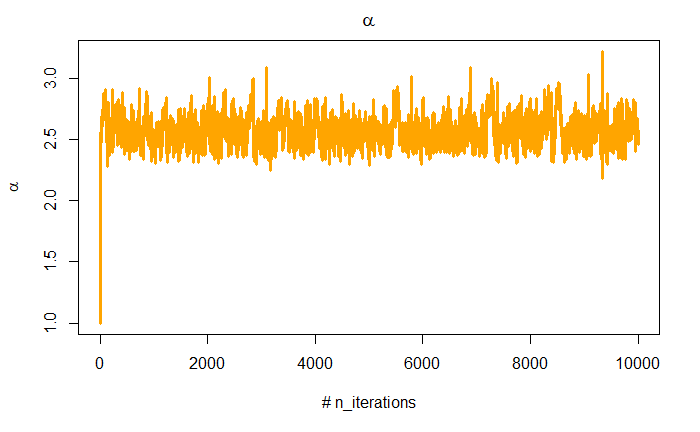

```r
plot(
  out_matrix[,1],
  type = 'l',
  main = expression(alpha),
  col = "orange",
  xlab = "# n_iterations",
  ylab = expression(alpha),
  lwd = 3
)
```

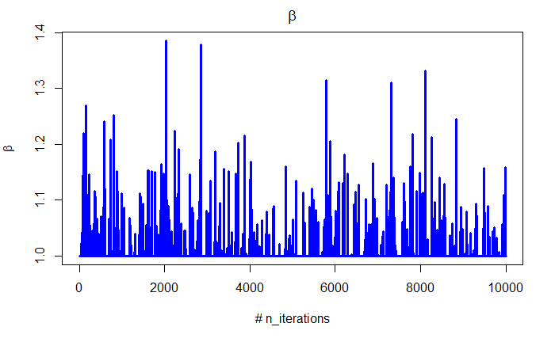

```r
plot(
  out_matrix[,2],
  type = 'l',
  main = expression(beta),
  col = "blue",
  xlab = "# n_iterations",
  ylab = expression(beta),
  lwd = 3
)
```

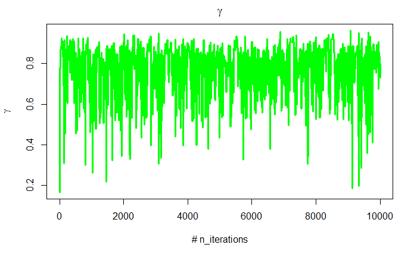

```r
plot(
  out_matrix[,3],
  type = 'l',
  main = expression(gamma),
  col = "green",
  xlab = "# n_iterations",
  ylab = expression(gamma),
  lwd = 3
)
```

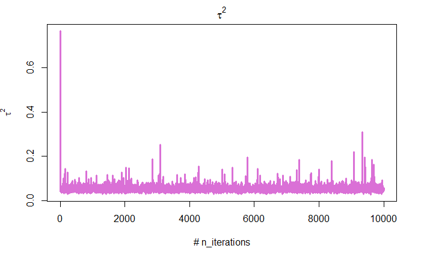

```r
plot(
  out_matrix[,4],
  type = 'l',
  main = expression(tau^2),
  col = "orchid",
  xlab = "# n_iterations",
  ylab = expression(tau^2),
  lwd = 3
)
```

### 1h) Evaluate graphically the behaviour of the empirical averages $\hat{I}_t$ with growing t = 1, …, T

As requested, let’s compare the empirical averages of each distribution (as the value of $t$ increases), with their mean:

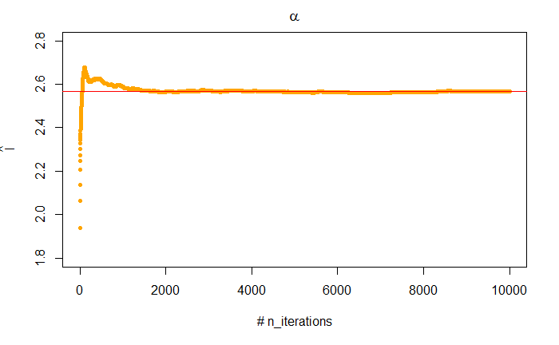

```r
target <- out_matrix[,1]

plot(
  cumsum(target) / (1:length(target)),
  ylim = c(1.8,2.8),
  xlab = '# n_iterations',
  ylab = expression(hat(I)),
  main = expression(alpha),
  col = "orange",
  pch = 20
)

abline(h = mean(target), col="red")
```

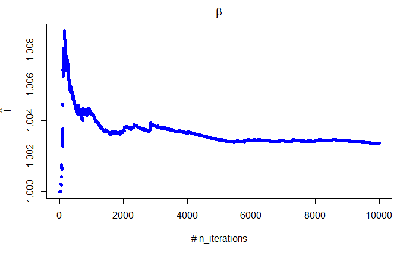

```r
target <- out_matrix[,2]

plot(
  cumsum(target) / (1:length(target)),
  xlab = '# n_iterations',
  ylab = expression(hat(I)),
  main = expression(beta),
  col = "blue",
  pch = 20
)

abline(h = mean(target), col="red")
```

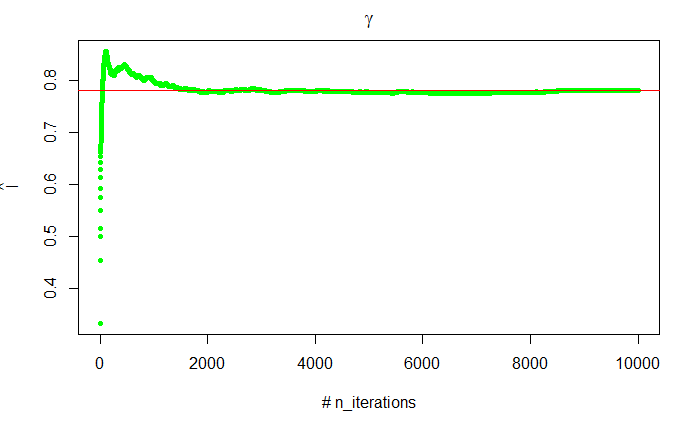

```r
target <- out_matrix[,3]

plot(
  cumsum(target) / (1:length(target)),
  xlab = '# n_iterations',
  ylab = expression(hat(I)),
  main = expression(gamma),
  col = "green",
  pch = 20
)

abline(h = mean(target), col="red")
```

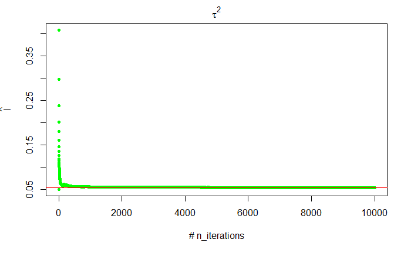

```r
target <- out_matrix[,4]

plot(
  cumsum(target) / (1:length(target)),
  xlab = '# n_iterations',
  ylab = expression(hat(I)),
  main = expression(tau^2),
  col = "green",
  pch = 20
)

abline(h = mean(target), col="red")
```

### 1i) Provide estimates for each parameter together with the approximation error and explain how you have evaluated such error

We will now estimate the mean and the approximation error for each of the parameters. To do so, we will omit the first $1000$ simulations (that correspond to the burn-in steps).

```r
burn_in_steps <- 1000

estimator_func <- function(target) {
  target_mean <- mean(target)
  sum_rho <- sum(acf(target, lag.max = Inf, plot=FALSE)$acf)
  t_inv <- length(target)/(length(target)/(1+2*sum_rho))
  target_error <- var(target) * t_inv

  return( c(target_mean, target_error) )
}
```

```r
target <- out_matrix[(burn_in_steps:n_n_iter),1]

res_alpha <- estimator_func(target)

print(paste("estimated mean for alpha is:",  round(res_alpha[1], 4) ))
print(paste("estimated error for alpha is:",  round(res_alpha[2], 4) ))
```

[output not shown]

```r
target <- out_matrix[(burn_in_steps:n_n_iter),2]

res_beta <- estimator_func(target)

print(paste("estimated mean for beta is:",  round(res_beta[1], 6) ))
print(paste("estimated error for beta is:",  round(res_beta[2], 6) ))
```

[output not shown]

```r
target <- out_matrix[(burn_in_steps:n_n_iter),3]

res_gamma <- estimator_func(target)

print(paste("estimated mean for gamma is:",  round(res_gamma[1], 4) ))
print(paste("estimated error for gamma is:",  round(res_gamma[2], 4) ))
```

[output not shown]

```r
target <- out_matrix[(burn_in_steps:n_n_iter),4]

res_tau2 <- estimator_func(target)

print(paste("estimated mean for tau2 is:",  round(res_tau2[1], 6) ))
print(paste("estimated error for tau2 is:",  round(res_tau2[2], 6) ))
```

[output not shown]

### 1l) Which parameter has the largest posterior uncertainty? How did you measure it?

In this case, the most simple way to measure the posterior uncertainties is to use the ratio of the approximated standard error and the mean:

```r
pu_alpha <- sqrt(res_alpha[2]) / res_alpha[1]
pu_beta <- sqrt(res_beta[2]) / res_beta[1]
pu_gamma <- sqrt(res_gamma[2]) / res_gamma[1]
pu_tau2 <- sqrt(res_tau2[2]) / res_tau2[1]

print(paste("The Posterior Uncertainty for alpha is:",  round(pu_alpha, 4) ))
print(paste("The Posterior Uncertainty for beta is:",  round(pu_beta, 4) ))
print(paste("The Posterior Uncertainty for gamma is:",  round(pu_gamma, 4) ))
print(paste("The Posterior Uncertainty for tau2 is:",  round(pu_tau2, 4) ))
```

[output not shown]

### 1m) Which couple of parameters has the largest correlation (in absolute value)?

```r
library(corrplot)

cor_matrix <- cor(out_matrix)[1:4,1:4]
colnames(cor_matrix) <- c("alpha", "beta", "gamma", "tau2")
rownames(cor_matrix) <- c("alpha", "beta", "gamma", "tau2")
corrplot(cor_matrix, method = "number")
```

[output not shown]

### 1n) Use the Markov chain to approximate the posterior predictive distribution of the length of a dugong with age of 20 years

```r
post_pred <- function(years) {
  set.seed(123)

  vec <- rep(NA, n_n_iter)

  alpha <- out_matrix[,1]
  beta <- out_matrix[,2]
  gamma <- out_matrix[,3]
  tau2 <- out_matrix[,4]

  for(i in 1:n_n_iter) {
    i_mean <- alpha[i] - beta[i]*(gamma[i]^years)
    i_sd <- sqrt(tau2[i])

    vec[i] <- rnorm(1, i_mean, i_sd)
  }

  return(vec)
}

mean(post_pred(20))
```

[output not shown]

As a result, we expect to see 20 years old Dugongs that measure approximately $2.53$ meters in length.

### 1o) Provide the prediction of a different dugong with age 30

Let’s reuse the function defined in the previous paragraph to also predict the length of a Dugong at the age of $30$:

```r
mean(post_pred(30))
```

[output not shown]

This means that we expect to see 30 years old Dugongs that measure approximately $2.56$ meters in length.

### 1p) Which prediction is less precise?

```r
yr20_prec <- 1 / var(post_pred(20))
yr30_prec <- 1 / var(post_pred(30))

round(yr20_prec, 3)
round(yr30_prec, 3)
```

[output not shown]

We have a higher precision level for the prediction related to 20 years old Dugongs. Hence, the prediction for the 30 years old Dugongs appears to be less precise.

## **Second Exercise**

### 2a) Starting at time t = 0 in the state X_{0} = 1 simulate the Markov chain with distribution assigned as above for t = 1000 consecutive times

From the provided illustration of the Markov chain, we can take out the probabilities and define the transition matrix:

```r
tm <- matrix(c(0, 1/2, 1/2, 5/8, 1/8, 1/4, 2/3, 1/3, 0), ncol = 3, byrow = TRUE)

tm
```

[output not shown]

We are now going to use the above transition matrix to run a simulation and observe how many times did we visit each state after a $1000$ steps (as requested, we are setting as initial state $X_{0} = 1$):

```r
start = 1
space_state <- c(1,2,3)
n_iter = 1000

sim_func = function(start, tm, n_iter, seed) {
  set.seed(seed)

  chain <- rep(NA, n_iter + 1)
  chain[1] <- start

  for(i in 1:n_iter) {
    chain[i + 1] <- sample(space_state, size = 1, prob = tm[chain[i],])
  }

  return(chain)
}

result <- sim_func(start, tm, n_iter, 123)

table(result)
```

[output not shown]

### 2b) compute the empirical relative frequency of the two states in your simulation

In the most straightforward way, we are simply turning the previous results into percentages:

```r
prop.table(table(result))
```

[output not shown]

### 2c) repeat the simulation for 500 times and record only the final state at time t = 1000 for each of the 500 simulated chains. Compute the relative frequency of the 500 final states. What distribution are you approximating in this way? Try to formalize the difference between this point and the previous point.

Below we repeat $500$ times the $1000$ steps simulation we did before, and plot the relative frequencies of the $500$ final states we achieve.

```r
n_chains = 500
seed <- 123
final_states = rep(NA, n_chains)

for(i in 1:n_chains) {
  current = sim_func(start, tm, n_iter, seed)
  final_states[i] = current[n_iter + 1]
  seed <- seed + 100
}

prop.table(table(final_states))
```

[output not shown]

A reason for doing so is to try to reduce the impact that the initial state has on the posterior distribution by giving more relevance to the “direction” the Markov Chain is heading to, which is more likely to be represented by the final state we observe after many steps. In other words, we are trying to approximate the distribution of the states in a stationary phase.

### 2d) compute the theoretical stationary distribution $\pi$ and explain how you have obtained it

If we consider a transition probability matrix with three possible states, then we can obtain the theoretical stationary distribution by solving the following system of equations:

$$\begin{equation}
\begin{cases}
\pi_{1} p_{11} + \pi_{2} p_{21} + \pi_{3} p_{31} = \pi_{1} \\
\pi_{1} p_{12} + \pi_{2} p_{22} + \pi_{3} p_{31} = \pi_{2} \\
\pi_{1} p_{13} + \pi_{2} p_{23} + \pi_{3} p_{33} = \pi_{3}
\end{cases}
\end{equation}$$

That can be written, in matrix notation, as:

$$\begin{equation}
(P^T - \lambda I) \pi = 0
\quad
with
\quad
P =
\begin{bmatrix}
p_{11} & p_{12} & p_{13} \\
p_{21} & p_{22} & p_{23}\\
p_{31} & p_{32} & p_{33}
\end{bmatrix}
,
\quad
\pi = (\pi_{1}, \pi_{2}, \pi_{3})^T
,
\quad
\pi_{1} + \pi_{2} + \pi_{3} = 1
,
\quad
\lambda = 1
\quad
\end{equation}$$

We can solve it as follows:

```r
result <- eigen(t(tm))$vector[,1] / sum(eigen(t(tm))$vector[,1])

result
```

[output not shown]

### 2e) is it well approximated by the simulated empirical relative frequencies computed in (b) and (c)?

To check how well we approximated the empirical relative frequencies, we can compare the results we got with the values returned in 2d):

```r
abs(prop.table(table(final_states)) - result)
```

[output not shown]

We notice immediately that the discrepancy is very small.

### 2f) what happens if we start at t = 0 from state $X_{0} = 2$ instead of $X_{0} = 1$?

Let’s repeat what we did so far, only this time assuming $X_{0} = 2$:

```r
start = 2
n_chains = 500
seed <- 123
final_states = rep(NA, n_chains)

for(i in 1:n_chains) {
  current = sim_func(start, tm, n_iter, seed)
  final_states[i] = current[n_iter + 1]
  seed <- seed + 100
}

abs(prop.table(table(final_states)) - result)
```

[output not shown]

We can see that we got the exact same results as when we started with $X_{0} = 1$. We can conlude that, no matter which initial state we choose, we will still eventually converge to the same distribution.